# Modèles de survie paramétriques

Ceci est un “notebook”. Il permet d’écrire du code au milieu du texte et d’afficher son résultat lorsque le document est compilé. Vous pouvez également utiliser les icones en haut à droite de chaque “chunk” (partie où se trouve le code), par exemple, la flèche verte permet de ne recompiler que cette partie.

Ce document est écrit en language markdown. Les bases qui vous permettront de comprendre la sytaxe sont juste que le “#” permet de définir le niveau du titre (“#” = titre 1; “##” = titre 1.1; “###” = titre 1.1.1;…). Le code R est écrit entre 2 balises, une d’ouverture du chunk et une de fermeture. Exemple:

```r
head(cars)
```

|  | speed | dist |
| --- | --- | --- |
| 1 | 4 | 2 |
| 2 | 4 | 10 |
| 3 | 7 | 4 |
| 4 | 7 | 22 |
| 5 | 8 | 16 |
| 6 | 9 | 10 |

Le résultat du code s’affiche en dessous si vous compilez le document, ou juste ce chunck en cliquant sur la flèche verte.

Finalement, lorsque votre document est terminé, vous pouvez obtenir une version clean en cliquant sur le bouton “preview” ou en tapant *Ctrl+Shift+K*. Un fichier de type html se trouve maintenant à côté de votre fichier Rmd, que vous pouvez garder pour vous ou envoyer à quelqu’un, il suffit d’un navigateur internet (même sans connexion) pour pouvoir l’afficher.

Revenons maintenant au cours…

# Pourquoi utiliser un modèle paramétrique ?

L’utilisation de modèles non-paramétrique ou semi-paramétrique (ex : Cox) présentent de nombreux avantages, mais également de nombreuses limites du fait de l’absence d’une forme structurée. En effet, le risque de base estimé par ces modèles est très fidèles aux données, mais trop pour pouvoir extrapoler à de nouvelles données.

Mais à quoi cela ressemble-t-il ?

```r
library(survival)
pts <- 0:100/30
sc <- 2
sh <- 1.5
XLAB = 'Temps (t)'
N <- 100
set.seed(1)
times <- rweibull(N, sh, sc)
event <- rep(1, N)
par(mfrow=c(1, 3), mar = c(5, 5, 2, 2) + .1, bty='l')
plot(survfit(Surv(times, event) ~ 1), ylim=0:1,main = 'Probabilité de survie\nS(t) = P(T > t)',ylab = '',xlab = XLAB, lwd=2, col='red', xmax = max(pts), conf.int = FALSE)
plot(0,0, ty='l',ylim=0:1,main = 'Densité de probabilité\nf(t) = -dS(t) / dt',ylab = '', xlab = XLAB, lwd=2, col='white')
```

```r
text(0,0.5,"?",cex=10)
plot(0,0, ty='l',ylim=0:1,main = 'Risque instantané\nh(t) = f(t) / S(t)',ylab = '', xlab = XLAB, lwd=2, col='white')
```

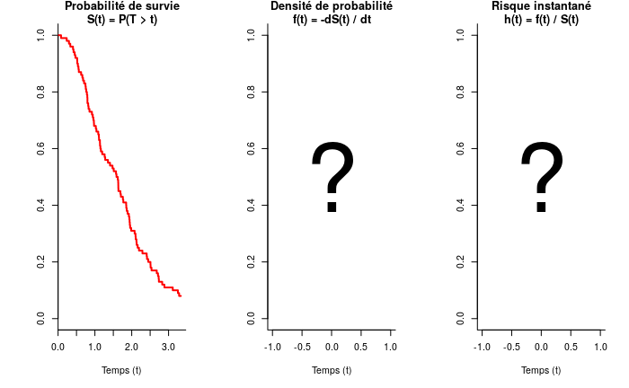

```r
text(0,0.5,"?",cex=10)
```

A chaque temps t, la pente de cette fonction est égale à 0 lorsqu’il n’y a pas d’évènement et à $\infty$ lorsqu’il y a un évènement. Lorsque l’on dérive cette distribution,on a donc :

```r
par(mfrow=c(1, 3), mar = c(5, 5, 2, 2) + .1, bty='l')
plot(survfit(Surv(times, event) ~ 1), ylim=0:1,main = 'Probabilité de survie\nS(t) = P(T > t)',ylab = '',xlab = XLAB, lwd=2, col='red', xmax = max(pts), conf.int = FALSE)
plot(times[event==1],rep(0,sum(event)),ylim=0:1,main = 'Densité de probabilité\nf(t) = -dS(t) / dt',ylab = '', xlab = XLAB, lwd=2, col='red')
```

```r
legend("topright","Event times",pch=1,col='red',bty="n")
abline(v=times[event==1],col="grey")
```

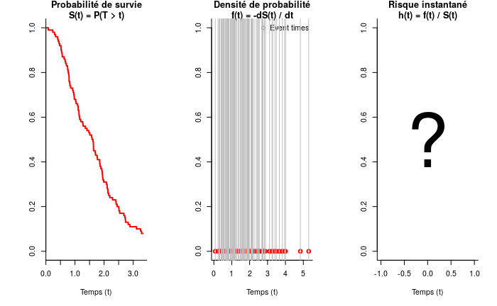

```r
plot(0,0, ty='l',ylim=0:1,main = 'Risque instantané\nh(t) = f(t) / S(t)',ylab = '', xlab = XLAB, lwd=2, col='white')
text(0,0.5,"?",cex=10)
```

Où chaque trait vertical correspond à une densité allant vers $\infty$ (car 1/0=$\infty$). La fonction de risque est donc également :

```r
par(mfrow=c(1, 3), mar = c(5, 5, 2, 2) + .1, bty='l')
plot(survfit(Surv(times, event) ~ 1), ylim=0:1,main = 'Probabilité de survie\nS(t) = P(T > t)',ylab = '',xlab = XLAB, lwd=2, col='red', xmax = max(pts), conf.int = FALSE)
plot(times[event==1],rep(0,sum(event)),ylim=0:1,main = 'Densité de probabilité\nf(t) = -dS(t) / dt',ylab = '', xlab = XLAB, lwd=2, col='red')
```

```r
legend("topright","Event times",pch=1,col='red',bty="n")
abline(v=times[event==1],col="grey")
```

```r
plot(times[event==1],rep(0,sum(event)),ylim=0:1,main = 'Risque instantané\nh(t) = f(t) / S(t)',ylab = '', xlab = XLAB, lwd=2, col='red')
legend("topright","Event times",pch=1,col='red',bty="n")
```

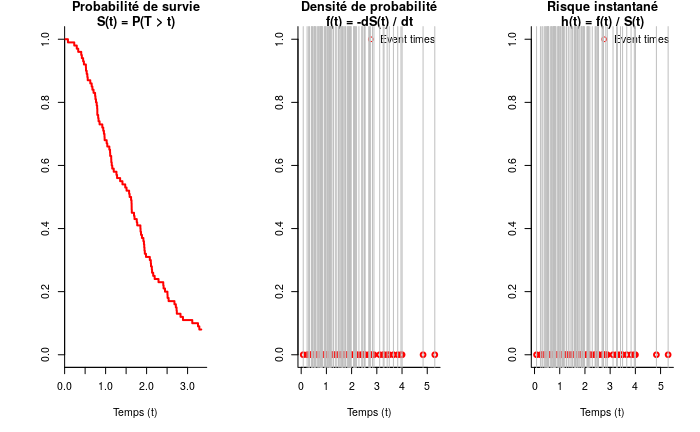

```r
abline(v=times[event==1],col="grey")
```

Dans un autre contexte, prenons les poids de souris mesurés lors d’une expérience. Utiliser une méthode non-paramétrique similaire reviendrait à avoir une distribution telle que celle-ci :

```r
N <- 50
set.seed(1)
x <- rnorm(N,20,7.5)
plot(x,rep(0,length(x)),ylim=0:1,main = 'Densité de probabilité',ylab = '', xlab = "Mouse weight (g)", lwd=2, col='red',bty='l')
legend("topright","Observations",pch=1,col='red',bty="n")
```

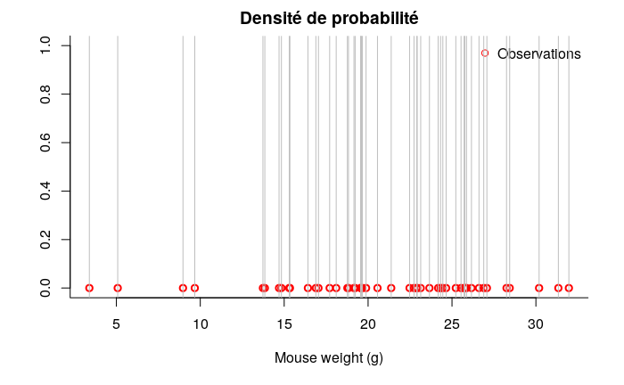

```r
abline(v=x,col="grey")
```

Il est clair qu’il est impossible de faire de la prédiction de nouvelles observations à partir de cette distribution. De ce fait, il est courant de placer une densité de probabilité sur ces points, représentant leur densité/concentration :

```r
plot(x,rep(0,length(x)),ylim=c(0,0.1),main = 'Densité de probabilité',ylab = '', xlab = "Mouse weight (g)", lwd=2, col='red',bty='l')
legend("topright","Observations",pch=1,col='red',bty="n")
```

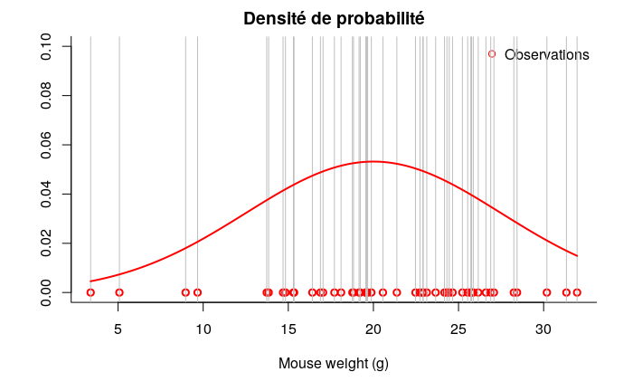

```r
abline(v=x,col="grey")
curve(dnorm(x,20,7.5),add=T,lwd=2,col='red')
```

Ici, on place un modèle gaussien sur les poids des souris. A partir de cela, nous pouvons : - calculer facilement des statistiques correspondantes à ces distributions (moyenne, médiane,…) grâce aux formules analytiques - faire de la prédiction - extrapoler en dehors des limites de l’échantillon - réaliser des études de simulations en tirant au hasard des valeurs dans cette distribution pour créer une population “synthétique” (souvent utilisée pour tester la robustesse d’un modèle ou faire du calcul de taille d’échantillon)

Cela permet également de restreindre le modèle pour limiter le sur-apprentissage, i.e. permettre d’avoir un modèle qui pourra extrapoler au delà de sa population d’apprentissage (cf cours modèles prédictifs).

Dans le cadre de la survie, nous aurons une fonction de survie plus lisse qu’un estimateur non-paramétrique et nous pouvons définir la densité de probabilité et la fonction de risque instantané :

```r
pts <- 0:100/30
sc <- 2
sh <- 1.5
XLAB = 'Temps (t)'
#par(xaxs='i', mfrow=c(1, 3), bty='l')
par( mfrow=c(1, 3), bty='l')
plot(pts, pweibull(pts, sh, sc, lower.tail = FALSE), ty='l', ylim=0:1,main = 'Probabilité de survie\nS(t) = P(T > t)',ylab = '', xlab = XLAB, lwd=2, col='red')
plot(pts, dweibull(pts, sh, sc), ty='l',main = 'Densité de probabilité\nf(t) = -dS(t) / dt',ylab = '', xlab = XLAB, lwd=2, col='red')
```

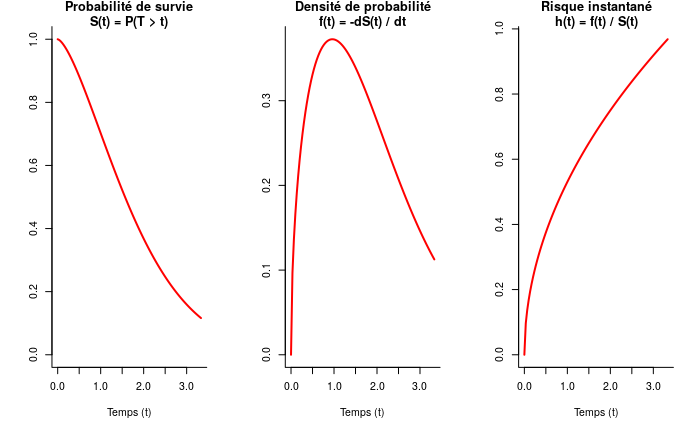

```r
plot(pts, dweibull(pts, sh, sc) / pweibull(pts, sh, sc, lower.tail = FALSE),ty='l', main = 'Risque instantané\nh(t) = f(t) / S(t)',ylab = '', xlab = XLAB, lwd=2, col='red')
```

# Dataset

Pour cette partie du TP, nous utiliserons le data “kidney” disponible dans le package survival.

```r
library('survival')
data('kidney')
head(kidney)
```

|  | id | time | status | age | sex | disease | frail |
| --- | --- | --- | --- | --- | --- | --- | --- |
| 1 | 1 | 8 | 1 | 28 | 1 | Other | 2.3 |
| 2 | 1 | 16 | 1 | 28 | 1 | Other | 2.3 |
| 3 | 2 | 23 | 1 | 48 | 2 | GN | 1.9 |
| 4 | 2 | 13 | 0 | 48 | 2 | GN | 1.9 |
| 5 | 3 | 22 | 1 | 32 | 1 | Other | 1.2 |
| 6 | 3 | 28 | 1 | 32 | 1 | Other | 1.2 |

# Distributions de survie paramétriques

## Récapitulatif

Dans ce TP, nous utiliserons les paraméterisations du package survival qui correspondent également à celle que vous pourrez rtetrouver dans certains documents, y compris les pages wikipedia de ces distributions. Afin de ne pas vous perdre, le tableau ci-dessous fait compare les fonctions de survie associées par rapport à celles que vous avez pu voir en cours.

| Famille | Package survival | Cours |
| --- | --- | --- |
| Exponentielle | $\exp(- \lambda t)$ | $\exp(- \lambda t)$ |
| Weibull | $\exp(- (\frac{t}{\lambda})^{\frac{1}{\sigma}})$ | $\exp(-(\lambda t)^\frac{1}{\sigma})$ |
| Log-normal | $1 - \Phi\left(\frac{\ln(t)-\mu}\sigma \right)$ | - |
| Log-logistique | $\frac{1}{1+\exp(\frac{\ln(t) - \mu)}{\sigma})}$ | $\frac{1}{1+(\lambda t)^{\gamma}}$ |

## Estimation de paramètres

### Distribution exponentielle

```r
fit_exp<-survreg(Surv(time,status) ~ 1, kidney,dist="exponential")
beta0_exp<-fit_exp$coef #extraction de la valeur de beta0
lambda_exp<-exp(-beta0_exp)
```

### Distribution de Weibull

```r
fit_weib<-survreg(Surv(time,status) ~ 1, kidney,dist="weibull")
beta0_weib<-fit_weib$coef #extraction de la valeur de beta0
lambda_weib<-exp(beta0_weib)
scale_weib<-fit_weib$scale
```

### Distribution de log-normale

```r
fit_logNorm<-survreg(Surv(time,status) ~ 1, kidney,dist="lognormal")
mu_logNorm<-fit_logNorm$coef
scale_logNorm<-fit_logNorm$scale
```

### Distribution de log-logistique

```r
fit_logLogi<-survreg(Surv(time,status) ~ 1, kidney,dist="loglogistic")
mu_logLogi<-fit_logLogi$coef
scale_logLogi<-fit_logLogi$scale
```

## Représentation graphique

```r
#par(mar = c(4, 4, .5, 0) + .1)
plot(survfit(Surv(time, status) ~ 1, data = kidney), conf.int = FALSE, xlab = 'Temps, t',ylab = bquote(paste(S(t))), col = "black")
curve(exp(-lambda_exp*x),add=T,col='red')
```

```r
curve(exp(-(x/lambda_weib)^(1/scale_weib)),add=T,col="green")
curve(1-pnorm((log(x)-mu_logNorm)/scale_logNorm),add=T,col="blue")
```

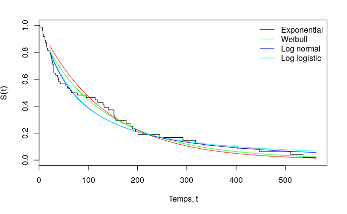

```r
curve(1/(1+exp((log(x)-mu_logLogi)/scale_logLogi)),add=T,col="cyan")
legend("topright",c("Exponential","Weibull","Log normal","Log logistic"),col=c("red","green","blue","cyan"),lty=1,bty="n")
```

## Médiane de survie

L’avantage d’avoir une distribution paramétrique et que nous avons des solutions analytiques qui nous permettent d’obtenir des statistiques facilement à partir de quelques formules bien connues (moyenne,…). La médiane de survie s’obtient facilement à partir de la fonction de répartition. Sous R, les fonctions des distribution usuelles peuvent être utilisée :

```r
qexp(0.5,lambda_exp)
```

```
[1] 92.30808
```

```r
qweibull(0.5,1/scale_weib,lambda_weib)
```

```
[1] 84.75924
```

```r
qlnorm(0.5,mu_logNorm,scale_logNorm)
```

```
[1] 68.30858
```

(Pour la log-logistique, d’autres packages sont nécessaire, ex : flexsurv)

On peut vérifier sur le plot

```r
par(mar = c(4, 4, .5, 0) + .1)
plot(survfit(Surv(time, status) ~ 1, data = kidney), conf.int = FALSE, xlab = 'Temps, t',ylab = bquote(paste(S(t))), col = "black")
curve(exp(-lambda_exp*x),add=T,col='red')
```

```r
curve(exp(-(x/lambda_weib)^(1/scale_weib)),add=T,col="green")
curve(1-pnorm((log(x)-mu_logNorm)/scale_logNorm),add=T,col="blue")
```

```r
curve(1/(1+exp((log(x)-mu_logLogi)/scale_logLogi)),add=T,col="cyan")
legend("topright",c("Exponential","Weibull","Log normal","Log logistic"),col=c("red","green","blue","cyan"),lty=1,bty="n")
```

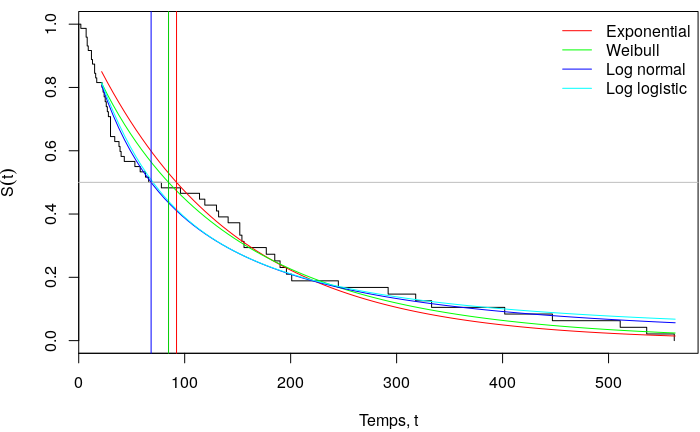

```r
abline(h=0.5,col="gray")
abline(v=c(qexp(0.5,lambda_exp),qweibull(0.5,1/scale_weib,lambda_weib),qlnorm(0.5,mu_logNorm,scale_logNorm)),col=2:4)
```

## Extrapolation

```r
par(mar = c(4, 4, .5, 0) + .1)
plot(survfit(Surv(time, status) ~ 1, data = kidney),xlim=c(0,1000), conf.int = FALSE, xlab = 'Temps, t',ylab = bquote(paste(S(t))), col = "black")
curve(exp(-lambda_exp*x),add=T,col='red')
```

```r
curve(exp(-(x/lambda_weib)^(1/scale_weib)),add=T,col="green")
curve(1-pnorm((log(x)-mu_logNorm)/scale_logNorm),add=T,col="blue")
```

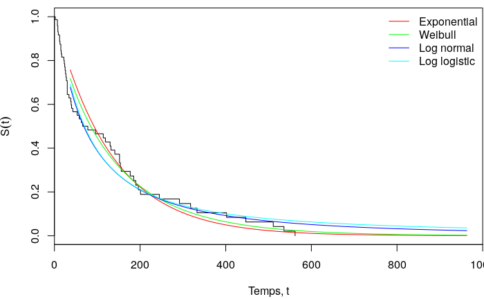

```r
curve(1/(1+exp((log(x)-mu_logLogi)/scale_logLogi)),add=T,col="cyan")
legend("topright",c("Exponential","Weibull","Log normal","Log logistic"),col=c("red","green","blue","cyan"),lty=1,bty="n")
```

## Prédiction

Réalisons des prédictions pour nos observations :

```r
predict(fit_weib)
```

```
 [1] 128.0324 128.0324 128.0324 128.0324 128.0324 128.0324 128.0324 128.0324 128.0324 128.0324 128.0324 128.0324 128.0324 128.0324 128.0324 128.0324 128.0324
[18] 128.0324 128.0324 128.0324 128.0324 128.0324 128.0324 128.0324 128.0324 128.0324 128.0324 128.0324 128.0324 128.0324 128.0324 128.0324 128.0324 128.0324
[35] 128.0324 128.0324 128.0324 128.0324 128.0324 128.0324 128.0324 128.0324 128.0324 128.0324 128.0324 128.0324 128.0324 128.0324 128.0324 128.0324 128.0324
[52] 128.0324 128.0324 128.0324 128.0324 128.0324 128.0324 128.0324 128.0324 128.0324 128.0324 128.0324 128.0324 128.0324 128.0324 128.0324 128.0324 128.0324
[69] 128.0324 128.0324 128.0324 128.0324 128.0324 128.0324 128.0324 128.0324
```

On peut constater que la moyenne de la distribution de Weibull est assigné à toutes les observations. Ces valeurs seront modifiées en fonction des facteurs d’ajustement pris en compte dans le modèle. Ex :

```r
fit_weib2<-survreg(Surv(time,status) ~ sex, kidney,dist="weibull")
#summary(fit_weib2)
#prediction pour sex = 0
print(paste0("Prédiction pour sex=0 : ",predict(fit_weib2,newdata = list(sex=0))))
```

```
[1] "Prédiction pour sex=0 : 22.3782038641622"
```

```r
#prediction pour sex = 1
print(paste0("Prédiction pour sex=1 : ",predict(fit_weib2,newdata = list(sex=1))))
```

```
[1] "Prédiction pour sex=1 : 60.0207658516785"
```

Mais quand on regarde le graphique, il y a peut être un meilleur modèle…

```r
plot(survfit(Surv(time, status) ~ sex, data = kidney), conf.int = FALSE, xlab = 'Temps, t',ylab = bquote(paste(S(t))), col=1:2)
p<-seq(0.01, 0.99, by=.01)
lines(x = predict(fit_weib2, type = "quantile", p = p,newdata=list(sex=rep(0,length(p))))[1,],y = rev(p),lty=2)
```

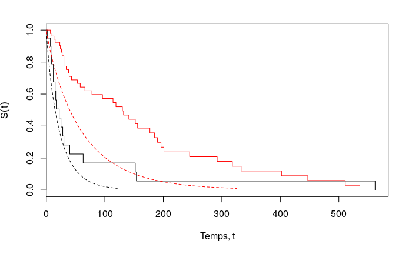

```r
lines(x = predict(fit_weib2, type = "quantile", p = p,newdata=list(sex=rep(1,length(p))))[1,],y = rev(p),col=2,lty=2)
```

## Comparaison des modèles

### Comparaison “intra-distribution”

Le dataset n’ayant pas beaucoup d’observations, le test de rapport de vraisemblance est à privilégier.

```r
anova(fit_weib,fit_weib2)
```

|  | Terms | Resid. Df | -2*LL | Test | Df | Deviance | Pr(>Chi) |
| --- | --- | --- | --- | --- | --- | --- | --- |
| 1 | 1 | 74 | 681.8749 |  | NA | NA | NA |
| 2 | sex | 73 | 673.2625 | = | 1 | 8.612403 | 0.003338815 |

Nous pouvons également regarder les critères AIC et BIC (plus faible est meilleur) :

```r
#AIC
extractAIC(fit_weib)
```

```
[1]   2.0000 685.8749
```

```r
extractAIC(fit_weib2)
```

```
[1]   3.0000 679.2625
```

```r
#BIC
extractAIC(fit_weib,k=log(nrow(kidney)))
```

```
[1]   2.0000 690.5363
```

```r
extractAIC(fit_weib2,k=log(nrow(kidney)))
```

```
[1]   3.0000 686.2547
```

Tous les critères indiquent que l’ajustement sur la variable sex permettent d’améliorer les performances du modèle.

### Comparaison “inter-distribution”

#### Comparaison modèles emboités

Le modèle exponentiel correspond au modèle de Weibull pour $\sigma=1$. Ces 2 modèles sont donc emboités et nous pouvons réaliser le test de rapport de vraisemblance.

```r
anova(fit_exp,fit_weib)
```

|  | Terms | Resid. Df | -2*LL | Test | Df | Deviance | Pr(>Chi) |
| --- | --- | --- | --- | --- | --- | --- | --- |
| 1 | 1 | 75 | 683.4308 |  | NA | NA | NA |
| 2 | 1 | 74 | 681.8749 | = | 1 | 1.555899 | 0.2122668 |

Regardons également les autres critères :

```r
#AIC
extractAIC(fit_exp)
```

```
[1]   1.0000 685.4308
```

```r
extractAIC(fit_weib)
```

```
[1]   2.0000 685.8749
```

```r
#BIC
extractAIC(fit_exp,k=log(nrow(kidney)))
```

```
[1]   1.0000 687.7615
```

```r
extractAIC(fit_weib,k=log(nrow(kidney)))
```

```
[1]   2.0000 690.5363
```

Dans tous les cas, les critères indique que le modèle de Weibull n’est pas meilleur que le modèle exponentiel. Le modèle exponentiel, plus simple, sera donc à privilégier.

#### Comparaison modèles non-emboités

Le rapport de vraisemblance n’est plus valable dans ce cas. Utilisons donc les autres critères :

```r
k=log(nrow(kidney))
data.frame(model=c("Exponentiel","Weibull","log-normal","log-logistique"),
           AIC=c(extractAIC(fit_exp)[2],extractAIC(fit_weib)[2],extractAIC(fit_logNorm)[2],extractAIC(fit_logLogi)[2]),
           BIC=c(extractAIC(fit_exp,k=k)[2],extractAIC(fit_weib,k=k)[2],extractAIC(fit_logNorm,k=k)[2],extractAIC(fit_logLogi,k=k)[2]))
```

| model | AIC | BIC |
| --- | --- | --- |
| Exponentiel | 685.4308 | 687.7615 |
| Weibull | 685.8749 | 690.5363 |
| log-normal | 684.0963 | 688.7578 |
| log-logistique | 688.0928 | 692.7543 |

Le modèle log-normal a le meilleur AIC, alors que le modèle exponentiel a le meilleur BIC. Cependant, les différences sont très faibles. Comme précédemment, le modèle le plus simplte (exponentiel) sera donc à favoriser.

Cependant, en prennant en compte un ajustement sur la variable sex, le modèle log-normal sera à privilégier.

```r
fit_exp2<-survreg(Surv(time,status) ~ sex, kidney,dist="exponential")
fit_logNorm2<-survreg(Surv(time,status) ~ sex, kidney,dist="lognormal")
fit_logLogi2<-survreg(Surv(time,status) ~ sex, kidney,dist="loglogistic")
k=log(nrow(kidney))
data.frame(model=c("Exponentiel","Weibull","log-normal","log-logistique"),
           AIC=c(extractAIC(fit_exp2)[2],extractAIC(fit_weib2)[2],extractAIC(fit_logNorm2)[2],extractAIC(fit_logLogi2)[2]),
           BIC=c(extractAIC(fit_exp2,k=k)[2],extractAIC(fit_weib2,k=k)[2],extractAIC(fit_logNorm2,k=k)[2],extractAIC(fit_logLogi2,k=k)[2]))
```

| model | AIC | BIC |
| --- | --- | --- |
| Exponentiel | 678.4875 | 683.1490 |
| Weibull | 679.2625 | 686.2547 |
| log-normal | 670.2552 | 677.2474 |
| log-logistique | 672.0271 | 679.0193 |